# Risk Factor Analysis

## Outcome Variable

**Outcome Variable:** ever_co

## Predictor Variables

**Intervention Variable:** nchldlt5

**Adjustment Set:**

- arm
- W_mage
- meducyrs
- feducyrs
- hhwealth_quart
- hfoodsec
- W_mhtcm
- W_mwtkg
- W_mbmi
- W_nrooms
- W_parity
- impfloor
- impsan
- safeh20
- delta_W_mage
- delta_meducyrs
- delta_feducyrs
- delta_hhwealth_quart
- delta_hfoodsec
- delta_W_mhtcm
- delta_W_mwtkg
- delta_W_mbmi
- delta_W_nrooms
- delta_W_parity
- delta_impfloor
- delta_impsan
- delta_safeh20

## Stratifying Variables

The analysis was stratified on these variable(s):

- agecat
- studyid
- country

## Data Summary

| agecat | studyid | country | nchldlt5 | ever_co | n_cell | n |
| --- | --- | --- | --- | --- | --- | --- |
| 0-24 months | iLiNS-Zinc | BURKINA FASO | 1 | 0 | 956 | 3188 |
| 0-24 months | iLiNS-Zinc | BURKINA FASO | 1 | 1 | 117 | 3188 |
| 0-24 months | iLiNS-Zinc | BURKINA FASO | 2+ | 0 | 1849 | 3188 |
| 0-24 months | iLiNS-Zinc | BURKINA FASO | 2+ | 1 | 266 | 3188 |
| 0-24 months | IRC | INDIA | 1 | 0 | 69 | 410 |
| 0-24 months | IRC | INDIA | 1 | 1 | 20 | 410 |
| 0-24 months | IRC | INDIA | 2+ | 0 | 265 | 410 |
| 0-24 months | IRC | INDIA | 2+ | 1 | 56 | 410 |
| 0-24 months | JiVitA-3 | BANGLADESH | 1 | 0 | 15656 | 26896 |
| 0-24 months | JiVitA-3 | BANGLADESH | 1 | 1 | 1540 | 26896 |
| 0-24 months | JiVitA-3 | BANGLADESH | 2+ | 0 | 8851 | 26896 |
| 0-24 months | JiVitA-3 | BANGLADESH | 2+ | 1 | 849 | 26896 |
| 0-24 months | LCNI-5 | MALAWI | 1 | 0 | 376 | 812 |
| 0-24 months | LCNI-5 | MALAWI | 1 | 1 | 15 | 812 |
| 0-24 months | LCNI-5 | MALAWI | 2+ | 0 | 394 | 812 |
| 0-24 months | LCNI-5 | MALAWI | 2+ | 1 | 27 | 812 |
| 0-24 months | NIH-Crypto | BANGLADESH | 1 | 0 | 496 | 758 |
| 0-24 months | NIH-Crypto | BANGLADESH | 1 | 1 | 45 | 758 |
| 0-24 months | NIH-Crypto | BANGLADESH | 2+ | 0 | 191 | 758 |
| 0-24 months | NIH-Crypto | BANGLADESH | 2+ | 1 | 26 | 758 |
| 0-24 months | PROVIDE | BANGLADESH | 1 | 0 | 447 | 700 |
| 0-24 months | PROVIDE | BANGLADESH | 1 | 1 | 65 | 700 |
| 0-24 months | PROVIDE | BANGLADESH | 2+ | 0 | 163 | 700 |
| 0-24 months | PROVIDE | BANGLADESH | 2+ | 1 | 25 | 700 |
| 0-24 months | TanzaniaChild2 | TANZANIA, UNITED REPUBLIC OF | 1 | 0 | 1552 | 2385 |
| 0-24 months | TanzaniaChild2 | TANZANIA, UNITED REPUBLIC OF | 1 | 1 | 85 | 2385 |
| 0-24 months | TanzaniaChild2 | TANZANIA, UNITED REPUBLIC OF | 2+ | 0 | 714 | 2385 |
| 0-24 months | TanzaniaChild2 | TANZANIA, UNITED REPUBLIC OF | 2+ | 1 | 34 | 2385 |
| 0-6 months | IRC | INDIA | 1 | 0 | 79 | 409 |
| 0-6 months | IRC | INDIA | 1 | 1 | 10 | 409 |
| 0-6 months | IRC | INDIA | 2+ | 0 | 305 | 409 |
| 0-6 months | IRC | INDIA | 2+ | 1 | 15 | 409 |
| 0-6 months | JiVitA-3 | BANGLADESH | 1 | 0 | 16380 | 26789 |
| 0-6 months | JiVitA-3 | BANGLADESH | 1 | 1 | 730 | 26789 |
| 0-6 months | JiVitA-3 | BANGLADESH | 2+ | 0 | 9347 | 26789 |
| 0-6 months | JiVitA-3 | BANGLADESH | 2+ | 1 | 332 | 26789 |
| 0-6 months | LCNI-5 | MALAWI | 1 | 0 | 122 | 267 |
| 0-6 months | LCNI-5 | MALAWI | 1 | 1 | 0 | 267 |
| 0-6 months | LCNI-5 | MALAWI | 2+ | 0 | 145 | 267 |
| 0-6 months | LCNI-5 | MALAWI | 2+ | 1 | 0 | 267 |
| 0-6 months | NIH-Crypto | BANGLADESH | 1 | 0 | 531 | 758 |
| 0-6 months | NIH-Crypto | BANGLADESH | 1 | 1 | 10 | 758 |
| 0-6 months | NIH-Crypto | BANGLADESH | 2+ | 0 | 210 | 758 |
| 0-6 months | NIH-Crypto | BANGLADESH | 2+ | 1 | 7 | 758 |
| 0-6 months | PROVIDE | BANGLADESH | 1 | 0 | 491 | 700 |
| 0-6 months | PROVIDE | BANGLADESH | 1 | 1 | 21 | 700 |
| 0-6 months | PROVIDE | BANGLADESH | 2+ | 0 | 179 | 700 |
| 0-6 months | PROVIDE | BANGLADESH | 2+ | 1 | 9 | 700 |
| 0-6 months | TanzaniaChild2 | TANZANIA, UNITED REPUBLIC OF | 1 | 0 | 1622 | 2385 |
| 0-6 months | TanzaniaChild2 | TANZANIA, UNITED REPUBLIC OF | 1 | 1 | 15 | 2385 |
| 0-6 months | TanzaniaChild2 | TANZANIA, UNITED REPUBLIC OF | 2+ | 0 | 744 | 2385 |
| 0-6 months | TanzaniaChild2 | TANZANIA, UNITED REPUBLIC OF | 2+ | 1 | 4 | 2385 |
| 6-24 months | iLiNS-Zinc | BURKINA FASO | 1 | 0 | 956 | 3188 |
| 6-24 months | iLiNS-Zinc | BURKINA FASO | 1 | 1 | 117 | 3188 |
| 6-24 months | iLiNS-Zinc | BURKINA FASO | 2+ | 0 | 1849 | 3188 |
| 6-24 months | iLiNS-Zinc | BURKINA FASO | 2+ | 1 | 266 | 3188 |
| 6-24 months | IRC | INDIA | 1 | 0 | 73 | 410 |
| 6-24 months | IRC | INDIA | 1 | 1 | 16 | 410 |
| 6-24 months | IRC | INDIA | 2+ | 0 | 273 | 410 |
| 6-24 months | IRC | INDIA | 2+ | 1 | 48 | 410 |
| 6-24 months | JiVitA-3 | BANGLADESH | 1 | 0 | 10266 | 17268 |
| 6-24 months | JiVitA-3 | BANGLADESH | 1 | 1 | 924 | 17268 |
| 6-24 months | JiVitA-3 | BANGLADESH | 2+ | 0 | 5503 | 17268 |
| 6-24 months | JiVitA-3 | BANGLADESH | 2+ | 1 | 575 | 17268 |
| 6-24 months | LCNI-5 | MALAWI | 1 | 0 | 369 | 800 |
| 6-24 months | LCNI-5 | MALAWI | 1 | 1 | 15 | 800 |
| 6-24 months | LCNI-5 | MALAWI | 2+ | 0 | 389 | 800 |
| 6-24 months | LCNI-5 | MALAWI | 2+ | 1 | 27 | 800 |
| 6-24 months | NIH-Crypto | BANGLADESH | 1 | 0 | 481 | 730 |
| 6-24 months | NIH-Crypto | BANGLADESH | 1 | 1 | 39 | 730 |
| 6-24 months | NIH-Crypto | BANGLADESH | 2+ | 0 | 186 | 730 |
| 6-24 months | NIH-Crypto | BANGLADESH | 2+ | 1 | 24 | 730 |
| 6-24 months | PROVIDE | BANGLADESH | 1 | 0 | 396 | 614 |
| 6-24 months | PROVIDE | BANGLADESH | 1 | 1 | 52 | 614 |
| 6-24 months | PROVIDE | BANGLADESH | 2+ | 0 | 143 | 614 |
| 6-24 months | PROVIDE | BANGLADESH | 2+ | 1 | 23 | 614 |
| 6-24 months | TanzaniaChild2 | TANZANIA, UNITED REPUBLIC OF | 1 | 0 | 1303 | 2009 |
| 6-24 months | TanzaniaChild2 | TANZANIA, UNITED REPUBLIC OF | 1 | 1 | 80 | 2009 |
| 6-24 months | TanzaniaChild2 | TANZANIA, UNITED REPUBLIC OF | 2+ | 0 | 593 | 2009 |
| 6-24 months | TanzaniaChild2 | TANZANIA, UNITED REPUBLIC OF | 2+ | 1 | 33 | 2009 |

The following strata were considered:

- agecat: 0-24 months, studyid: iLiNS-Zinc, country: BURKINA FASO
- agecat: 0-24 months, studyid: IRC, country: INDIA
- agecat: 0-24 months, studyid: JiVitA-3, country: BANGLADESH
- agecat: 0-24 months, studyid: LCNI-5, country: MALAWI
- agecat: 0-24 months, studyid: NIH-Crypto, country: BANGLADESH
- agecat: 0-24 months, studyid: PROVIDE, country: BANGLADESH
- agecat: 0-24 months, studyid: TanzaniaChild2, country: TANZANIA, UNITED REPUBLIC OF
- agecat: 0-6 months, studyid: IRC, country: INDIA
- agecat: 0-6 months, studyid: JiVitA-3, country: BANGLADESH
- agecat: 0-6 months, studyid: LCNI-5, country: MALAWI
- agecat: 0-6 months, studyid: NIH-Crypto, country: BANGLADESH
- agecat: 0-6 months, studyid: PROVIDE, country: BANGLADESH
- agecat: 0-6 months, studyid: TanzaniaChild2, country: TANZANIA, UNITED REPUBLIC OF
- agecat: 6-24 months, studyid: iLiNS-Zinc, country: BURKINA FASO
- agecat: 6-24 months, studyid: IRC, country: INDIA
- agecat: 6-24 months, studyid: JiVitA-3, country: BANGLADESH
- agecat: 6-24 months, studyid: LCNI-5, country: MALAWI
- agecat: 6-24 months, studyid: NIH-Crypto, country: BANGLADESH
- agecat: 6-24 months, studyid: PROVIDE, country: BANGLADESH
- agecat: 6-24 months, studyid: TanzaniaChild2, country: TANZANIA, UNITED REPUBLIC OF

### Dropped Strata

Some strata were dropped due to rare outcomes:

- agecat: 0-6 months, studyid: LCNI-5, country: MALAWI
- agecat: 0-6 months, studyid: TanzaniaChild2, country: TANZANIA, UNITED REPUBLIC OF

## Methods Detail

We’re interested in the causal parameters $E[Y_a]$ for all values of $a \in \mathcal{A}$. These parameters represent the mean outcome if, possibly contrary to fact, we intervened to set all units to have $A=a$. Under the randomization and positivity assumptions, these are identified by the statistical parameters $\psi_a=E_W[E_{Y|A,W}(Y|A=a,W)]$. In addition, we’re interested in the mean of $Y$, $E[Y]$ under no intervention (the observed mean). We will estimate these parameters by using SuperLearner to fit the relevant likelihood factors – $E_{Y|A,W}(Y|A=a,W)$ and $p(A=a|W)$, and then updating our likelihood fit using a joint TMLE.

For unadjusted analyses ($W=\{\}$), initial likelihoods were estimated using Lrnr_glm to estimate the simple $E(Y|A)$ and Lrnr_mean to estimate $p(A)$. For adjusted analyses, a small library containing Lrnr_glmnet, Lrnr_xgboost, and Lrnr_mean was used.

Having estimated these parameters, we will then use the delta method to estimate relative risks and attributable risks relative to a prespecified baseline level of $A$.

# Results Detail

## Results Plots

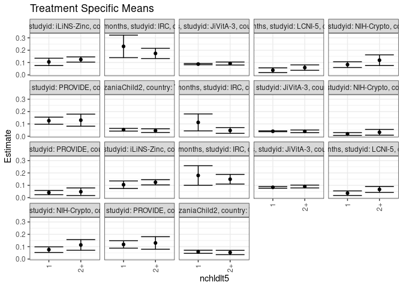

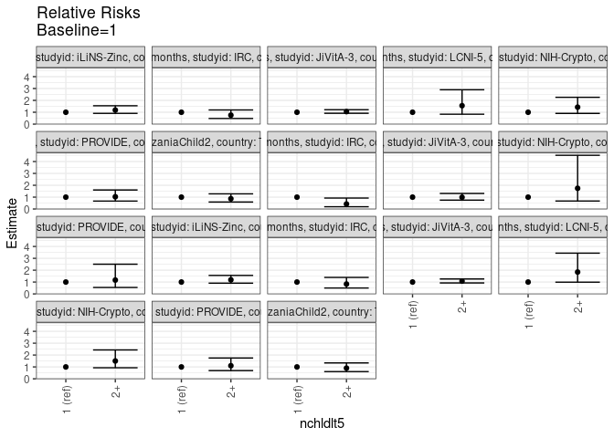

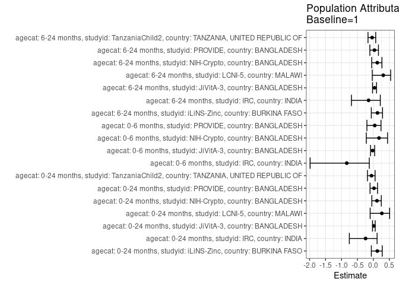

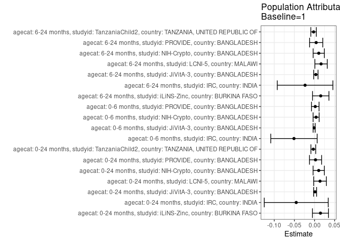

## Results Table

### Parameter: TSM

| agecat | studyid | country | intervention_level | baseline_level | estimate | ci_lower | ci_upper |
| --- | --- | --- | --- | --- | --- | --- | --- |
| 0-24 months | iLiNS-Zinc | BURKINA FASO | 1 | NA | 0.1053122 | 0.0755729 | 0.1350514 |
| 0-24 months | iLiNS-Zinc | BURKINA FASO | 2+ | NA | 0.1246367 | 0.1035328 | 0.1457405 |
| 0-24 months | IRC | INDIA | 1 | NA | 0.2307648 | 0.1395756 | 0.3219540 |
| 0-24 months | IRC | INDIA | 2+ | NA | 0.1738743 | 0.1323587 | 0.2153898 |
| 0-24 months | JiVitA-3 | BANGLADESH | 1 | NA | 0.0874170 | 0.0821813 | 0.0926528 |
| 0-24 months | JiVitA-3 | BANGLADESH | 2+ | NA | 0.0919773 | 0.0797752 | 0.1041795 |
| 0-24 months | LCNI-5 | MALAWI | 1 | NA | 0.0380065 | 0.0188999 | 0.0571131 |
| 0-24 months | LCNI-5 | MALAWI | 2+ | NA | 0.0590367 | 0.0372692 | 0.0808042 |
| 0-24 months | NIH-Crypto | BANGLADESH | 1 | NA | 0.0832126 | 0.0599417 | 0.1064834 |
| 0-24 months | NIH-Crypto | BANGLADESH | 2+ | NA | 0.1188790 | 0.0755304 | 0.1622275 |
| 0-24 months | PROVIDE | BANGLADESH | 1 | NA | 0.1260565 | 0.0972301 | 0.1548830 |
| 0-24 months | PROVIDE | BANGLADESH | 2+ | NA | 0.1303467 | 0.0814627 | 0.1792308 |
| 0-24 months | TanzaniaChild2 | TANZANIA, UNITED REPUBLIC OF | 1 | NA | 0.0528597 | 0.0418648 | 0.0638546 |
| 0-24 months | TanzaniaChild2 | TANZANIA, UNITED REPUBLIC OF | 2+ | NA | 0.0457997 | 0.0307801 | 0.0608193 |
| 0-6 months | IRC | INDIA | 1 | NA | 0.1121424 | 0.0434216 | 0.1808632 |
| 0-6 months | IRC | INDIA | 2+ | NA | 0.0470580 | 0.0237499 | 0.0703661 |
| 0-6 months | JiVitA-3 | BANGLADESH | 1 | NA | 0.0405500 | 0.0369880 | 0.0441119 |
| 0-6 months | JiVitA-3 | BANGLADESH | 2+ | NA | 0.0401467 | 0.0293694 | 0.0509240 |
| 0-6 months | NIH-Crypto | BANGLADESH | 1 | NA | 0.0184843 | 0.0071267 | 0.0298419 |
| 0-6 months | NIH-Crypto | BANGLADESH | 2+ | NA | 0.0322581 | 0.0087345 | 0.0557817 |
| 0-6 months | PROVIDE | BANGLADESH | 1 | NA | 0.0410156 | 0.0238245 | 0.0582067 |
| 0-6 months | PROVIDE | BANGLADESH | 2+ | NA | 0.0478723 | 0.0173323 | 0.0784124 |
| 6-24 months | iLiNS-Zinc | BURKINA FASO | 1 | NA | 0.1047008 | 0.0741255 | 0.1352761 |
| 6-24 months | iLiNS-Zinc | BURKINA FASO | 2+ | NA | 0.1242141 | 0.1030286 | 0.1453996 |
| 6-24 months | IRC | INDIA | 1 | NA | 0.1795307 | 0.1004456 | 0.2586158 |
| 6-24 months | IRC | INDIA | 2+ | NA | 0.1491479 | 0.1101610 | 0.1881348 |
| 6-24 months | JiVitA-3 | BANGLADESH | 1 | NA | 0.0835078 | 0.0763899 | 0.0906257 |
| 6-24 months | JiVitA-3 | BANGLADESH | 2+ | NA | 0.0900697 | 0.0786433 | 0.1014961 |
| 6-24 months | LCNI-5 | MALAWI | 1 | NA | 0.0361807 | 0.0177551 | 0.0546063 |
| 6-24 months | LCNI-5 | MALAWI | 2+ | NA | 0.0666597 | 0.0426248 | 0.0906947 |
| 6-24 months | NIH-Crypto | BANGLADESH | 1 | NA | 0.0757583 | 0.0531067 | 0.0984099 |
| 6-24 months | NIH-Crypto | BANGLADESH | 2+ | NA | 0.1138916 | 0.0709223 | 0.1568609 |
| 6-24 months | PROVIDE | BANGLADESH | 1 | NA | 0.1180446 | 0.0881136 | 0.1479756 |
| 6-24 months | PROVIDE | BANGLADESH | 2+ | NA | 0.1300303 | 0.0791890 | 0.1808717 |
| 6-24 months | TanzaniaChild2 | TANZANIA, UNITED REPUBLIC OF | 1 | NA | 0.0585320 | 0.0460387 | 0.0710254 |
| 6-24 months | TanzaniaChild2 | TANZANIA, UNITED REPUBLIC OF | 2+ | NA | 0.0527427 | 0.0352580 | 0.0702274 |

### Parameter: E(Y)

| agecat | studyid | country | intervention_level | baseline_level | estimate | ci_lower | ci_upper |
| --- | --- | --- | --- | --- | --- | --- | --- |
| 0-24 months | iLiNS-Zinc | BURKINA FASO | NA | NA | 0.1201380 | 0.1003403 | 0.1399357 |
| 0-24 months | IRC | INDIA | NA | NA | 0.1853659 | 0.1477057 | 0.2230261 |
| 0-24 months | JiVitA-3 | BANGLADESH | NA | NA | 0.0888236 | 0.0849161 | 0.0927312 |
| 0-24 months | LCNI-5 | MALAWI | NA | NA | 0.0517241 | 0.0364818 | 0.0669665 |
| 0-24 months | NIH-Crypto | BANGLADESH | NA | NA | 0.0936675 | 0.0729118 | 0.1144233 |
| 0-24 months | PROVIDE | BANGLADESH | NA | NA | 0.1285714 | 0.1037574 | 0.1533855 |
| 0-24 months | TanzaniaChild2 | TANZANIA, UNITED REPUBLIC OF | NA | NA | 0.0498952 | 0.0411552 | 0.0586352 |
| 0-6 months | IRC | INDIA | NA | NA | 0.0611247 | 0.0378797 | 0.0843697 |
| 0-6 months | JiVitA-3 | BANGLADESH | NA | NA | 0.0396431 | 0.0371403 | 0.0421459 |
| 0-6 months | NIH-Crypto | BANGLADESH | NA | NA | 0.0224274 | 0.0118796 | 0.0329753 |
| 0-6 months | PROVIDE | BANGLADESH | NA | NA | 0.0428571 | 0.0278427 | 0.0578716 |
| 6-24 months | iLiNS-Zinc | BURKINA FASO | NA | NA | 0.1201380 | 0.1003403 | 0.1399357 |
| 6-24 months | IRC | INDIA | NA | NA | 0.1560976 | 0.1209228 | 0.1912723 |
| 6-24 months | JiVitA-3 | BANGLADESH | NA | NA | 0.0868080 | 0.0821488 | 0.0914672 |
| 6-24 months | LCNI-5 | MALAWI | NA | NA | 0.0525000 | 0.0370352 | 0.0679648 |
| 6-24 months | NIH-Crypto | BANGLADESH | NA | NA | 0.0863014 | 0.0659171 | 0.1066856 |
| 6-24 months | PROVIDE | BANGLADESH | NA | NA | 0.1221498 | 0.0962275 | 0.1480722 |
| 6-24 months | TanzaniaChild2 | TANZANIA, UNITED REPUBLIC OF | NA | NA | 0.0562469 | 0.0461696 | 0.0663242 |

### Parameter: RR

| agecat | studyid | country | intervention_level | baseline_level | estimate | ci_lower | ci_upper |
| --- | --- | --- | --- | --- | --- | --- | --- |
| 0-24 months | iLiNS-Zinc | BURKINA FASO | 1 | 1 | 1.0000000 | 1.0000000 | 1.0000000 |
| 0-24 months | iLiNS-Zinc | BURKINA FASO | 2+ | 1 | 1.1834971 | 0.9051391 | 1.5474588 |
| 0-24 months | IRC | INDIA | 1 | 1 | 1.0000000 | 1.0000000 | 1.0000000 |
| 0-24 months | IRC | INDIA | 2+ | 1 | 0.7534698 | 0.4755041 | 1.1939261 |
| 0-24 months | JiVitA-3 | BANGLADESH | 1 | 1 | 1.0000000 | 1.0000000 | 1.0000000 |
| 0-24 months | JiVitA-3 | BANGLADESH | 2+ | 1 | 1.0521671 | 0.9132202 | 1.2122550 |
| 0-24 months | LCNI-5 | MALAWI | 1 | 1 | 1.0000000 | 1.0000000 | 1.0000000 |
| 0-24 months | LCNI-5 | MALAWI | 2+ | 1 | 1.5533315 | 0.8329955 | 2.8965811 |
| 0-24 months | NIH-Crypto | BANGLADESH | 1 | 1 | 1.0000000 | 1.0000000 | 1.0000000 |
| 0-24 months | NIH-Crypto | BANGLADESH | 2+ | 1 | 1.4286181 | 0.9029646 | 2.2602767 |
| 0-24 months | PROVIDE | BANGLADESH | 1 | 1 | 1.0000000 | 1.0000000 | 1.0000000 |
| 0-24 months | PROVIDE | BANGLADESH | 2+ | 1 | 1.0340340 | 0.6670030 | 1.6030308 |
| 0-24 months | TanzaniaChild2 | TANZANIA, UNITED REPUBLIC OF | 1 | 1 | 1.0000000 | 1.0000000 | 1.0000000 |
| 0-24 months | TanzaniaChild2 | TANZANIA, UNITED REPUBLIC OF | 2+ | 1 | 0.8664379 | 0.5875197 | 1.2777695 |
| 0-6 months | IRC | INDIA | 1 | 1 | 1.0000000 | 1.0000000 | 1.0000000 |
| 0-6 months | IRC | INDIA | 2+ | 1 | 0.4196272 | 0.1906140 | 0.9237882 |
| 0-6 months | JiVitA-3 | BANGLADESH | 1 | 1 | 1.0000000 | 1.0000000 | 1.0000000 |
| 0-6 months | JiVitA-3 | BANGLADESH | 2+ | 1 | 0.9900552 | 0.7472438 | 1.3117663 |
| 0-6 months | NIH-Crypto | BANGLADESH | 1 | 1 | 1.0000000 | 1.0000000 | 1.0000000 |
| 0-6 months | NIH-Crypto | BANGLADESH | 2+ | 1 | 1.7451613 | 0.6725110 | 4.5286814 |
| 0-6 months | PROVIDE | BANGLADESH | 1 | 1 | 1.0000000 | 1.0000000 | 1.0000000 |
| 0-6 months | PROVIDE | BANGLADESH | 2+ | 1 | 1.1671733 | 0.5440406 | 2.5040289 |
| 6-24 months | iLiNS-Zinc | BURKINA FASO | 1 | 1 | 1.0000000 | 1.0000000 | 1.0000000 |
| 6-24 months | iLiNS-Zinc | BURKINA FASO | 2+ | 1 | 1.1863717 | 0.9034328 | 1.5579219 |
| 6-24 months | IRC | INDIA | 1 | 1 | 1.0000000 | 1.0000000 | 1.0000000 |
| 6-24 months | IRC | INDIA | 2+ | 1 | 0.8307655 | 0.4976915 | 1.3867453 |
| 6-24 months | JiVitA-3 | BANGLADESH | 1 | 1 | 1.0000000 | 1.0000000 | 1.0000000 |
| 6-24 months | JiVitA-3 | BANGLADESH | 2+ | 1 | 1.0785787 | 0.9251605 | 1.2574381 |
| 6-24 months | LCNI-5 | MALAWI | 1 | 1 | 1.0000000 | 1.0000000 | 1.0000000 |
| 6-24 months | LCNI-5 | MALAWI | 2+ | 1 | 1.8424114 | 0.9883377 | 3.4345343 |
| 6-24 months | NIH-Crypto | BANGLADESH | 1 | 1 | 1.0000000 | 1.0000000 | 1.0000000 |
| 6-24 months | NIH-Crypto | BANGLADESH | 2+ | 1 | 1.5033550 | 0.9297354 | 2.4308813 |
| 6-24 months | PROVIDE | BANGLADESH | 1 | 1 | 1.0000000 | 1.0000000 | 1.0000000 |
| 6-24 months | PROVIDE | BANGLADESH | 2+ | 1 | 1.1015355 | 0.6922239 | 1.7528729 |
| 6-24 months | TanzaniaChild2 | TANZANIA, UNITED REPUBLIC OF | 1 | 1 | 1.0000000 | 1.0000000 | 1.0000000 |
| 6-24 months | TanzaniaChild2 | TANZANIA, UNITED REPUBLIC OF | 2+ | 1 | 0.9010909 | 0.6074009 | 1.3367855 |

### Parameter: PAR

| agecat | studyid | country | intervention_level | baseline_level | estimate | ci_lower | ci_upper |
| --- | --- | --- | --- | --- | --- | --- | --- |
| 0-24 months | iLiNS-Zinc | BURKINA FASO | 1 | NA | 0.0148258 | -0.0051540 | 0.0348057 |
| 0-24 months | IRC | INDIA | 1 | NA | -0.0453989 | -0.1248254 | 0.0340276 |
| 0-24 months | JiVitA-3 | BANGLADESH | 1 | NA | 0.0014066 | -0.0023243 | 0.0051375 |
| 0-24 months | LCNI-5 | MALAWI | 1 | NA | 0.0137176 | -0.0021235 | 0.0295588 |
| 0-24 months | NIH-Crypto | BANGLADESH | 1 | NA | 0.0104550 | -0.0035957 | 0.0245056 |
| 0-24 months | PROVIDE | BANGLADESH | 1 | NA | 0.0025149 | -0.0125771 | 0.0176068 |
| 0-24 months | TanzaniaChild2 | TANZANIA, UNITED REPUBLIC OF | 1 | NA | -0.0029645 | -0.0089231 | 0.0029940 |
| 0-6 months | IRC | INDIA | 1 | NA | -0.0510177 | -0.1086274 | 0.0065919 |
| 0-6 months | JiVitA-3 | BANGLADESH | 1 | NA | -0.0009068 | -0.0034778 | 0.0016641 |
| 0-6 months | NIH-Crypto | BANGLADESH | 1 | NA | 0.0039432 | -0.0035482 | 0.0114345 |
| 0-6 months | PROVIDE | BANGLADESH | 1 | NA | 0.0018415 | -0.0075736 | 0.0112566 |
| 6-24 months | iLiNS-Zinc | BURKINA FASO | 1 | NA | 0.0154372 | -0.0050101 | 0.0358845 |
| 6-24 months | IRC | INDIA | 1 | NA | -0.0234331 | -0.0925003 | 0.0456341 |
| 6-24 months | JiVitA-3 | BANGLADESH | 1 | NA | 0.0033002 | -0.0021165 | 0.0087168 |
| 6-24 months | LCNI-5 | MALAWI | 1 | NA | 0.0163193 | 0.0009696 | 0.0316690 |
| 6-24 months | NIH-Crypto | BANGLADESH | 1 | NA | 0.0105431 | -0.0034159 | 0.0245021 |
| 6-24 months | PROVIDE | BANGLADESH | 1 | NA | 0.0041052 | -0.0123368 | 0.0205473 |
| 6-24 months | TanzaniaChild2 | TANZANIA, UNITED REPUBLIC OF | 1 | NA | -0.0022852 | -0.0090910 | 0.0045207 |

### Parameter: PAF

| agecat | studyid | country | intervention_level | baseline_level | estimate | ci_lower | ci_upper |
| --- | --- | --- | --- | --- | --- | --- | --- |
| 0-24 months | iLiNS-Zinc | BURKINA FASO | 1 | NA | 0.1234068 | -0.0640873 | 0.2778640 |
| 0-24 months | IRC | INDIA | 1 | NA | -0.2449152 | -0.7535461 | 0.1161830 |
| 0-24 months | JiVitA-3 | BANGLADESH | 1 | NA | 0.0158356 | -0.0270390 | 0.0569203 |
| 0-24 months | LCNI-5 | MALAWI | 1 | NA | 0.2652077 | -0.1007333 | 0.5094909 |
| 0-24 months | NIH-Crypto | BANGLADESH | 1 | NA | 0.1116180 | -0.0498490 | 0.2482514 |
| 0-24 months | PROVIDE | BANGLADESH | 1 | NA | 0.0195603 | -0.1051345 | 0.1301855 |
| 0-24 months | TanzaniaChild2 | TANZANIA, UNITED REPUBLIC OF | 1 | NA | -0.0594153 | -0.1853280 | 0.0531221 |
| 0-6 months | IRC | INDIA | 1 | NA | -0.8346498 | -1.9838272 | -0.1280612 |
| 0-6 months | JiVitA-3 | BANGLADESH | 1 | NA | -0.0228747 | -0.0898670 | 0.0399997 |
| 0-6 months | NIH-Crypto | BANGLADESH | 1 | NA | 0.1758182 | -0.2211410 | 0.4437370 |
| 0-6 months | PROVIDE | BANGLADESH | 1 | NA | 0.0429687 | -0.2033820 | 0.2388877 |
| 6-24 months | iLiNS-Zinc | BURKINA FASO | 1 | NA | 0.1284956 | -0.0649700 | 0.2868157 |
| 6-24 months | IRC | INDIA | 1 | NA | -0.1501184 | -0.6891137 | 0.2168838 |
| 6-24 months | JiVitA-3 | BANGLADESH | 1 | NA | 0.0380169 | -0.0264685 | 0.0984512 |
| 6-24 months | LCNI-5 | MALAWI | 1 | NA | 0.3108439 | -0.0351595 | 0.5411953 |
| 6-24 months | NIH-Crypto | BANGLADESH | 1 | NA | 0.1221659 | -0.0525889 | 0.2679073 |
| 6-24 months | PROVIDE | BANGLADESH | 1 | NA | 0.0336081 | -0.1105930 | 0.1590859 |
| 6-24 months | TanzaniaChild2 | TANZANIA, UNITED REPUBLIC OF | 1 | NA | -0.0406272 | -0.1686992 | 0.0734099 |